# Associations

## Earnings and Infant Mortality in 1960

```r
gap1960 <- gapminder %>%
  filter(year == 1960 & !is.na(gdp) & !is.na(infant_mortality)) %>%
  mutate(dollars_per_day = gdp/population/365) %>%
  mutate(infant_survival_rate = 1 - infant_mortality/1000)
head(gap1960)
```

```
##      country year infant_mortality life_expectancy fertility population
## 1    Algeria 1960           148.20           47.50      7.65   11124892
## 2  Argentina 1960            59.87           65.39      3.11   20619075
## 3  Australia 1960            20.30           70.87      3.45   10292328
## 4    Austria 1960            37.30           68.75      2.70    7065525
## 5    Bahamas 1960            51.00           62.00      4.50     109526
## 6 Bangladesh 1960           176.30           46.20      6.73   48200702
##            gdp continent                    region dollars_per_day
## 1  13828152297    Africa           Northern Africa       3.4054577
## 2 108322326649  Americas             South America      14.3931528
## 3  96677859364   Oceania Australia and New Zealand      25.7347849
## 4  52392699681    Europe            Western Europe      20.3157788
## 5   1306269490  Americas                 Caribbean      32.6755339
## 6  12767231590      Asia             Southern Asia       0.7256889
##   infant_survival_rate
## 1              0.85180
## 2              0.94013
## 3              0.97970
## 4              0.96270
## 5              0.94900
## 6              0.82370
```

Following the same process as used for the 2010 data, we can filter out the `gapminder` data for the year 1960, and compute the “dollars per day” and “infant survival rate” metrics.

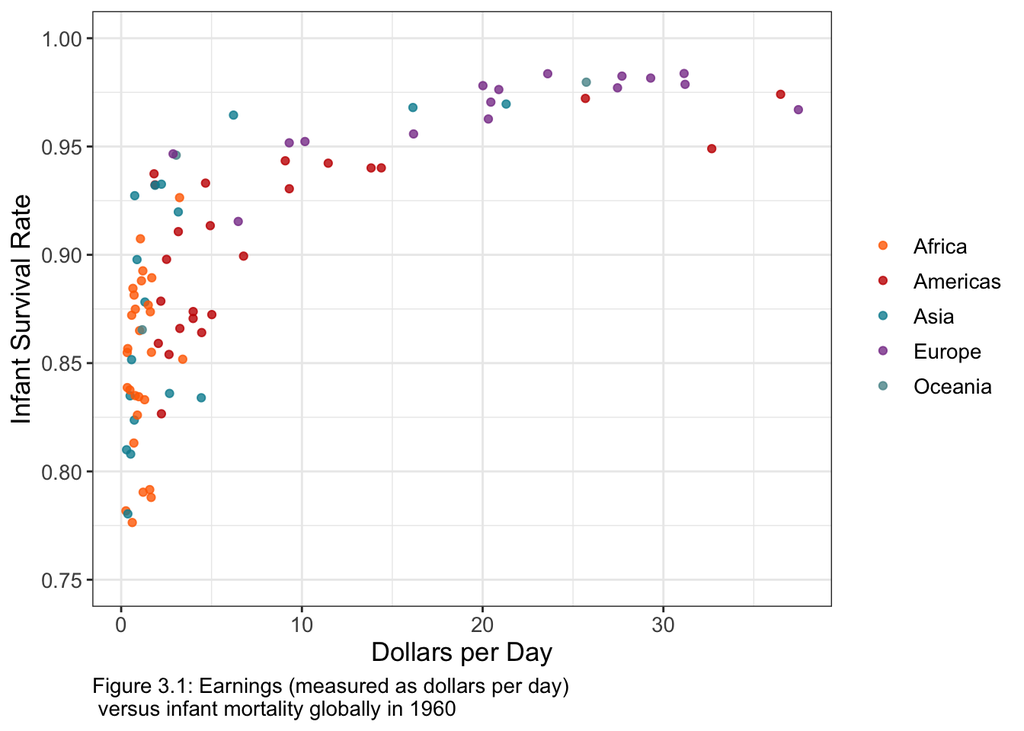

```r
plot2 <- ggplot() + geom_point(data = gap1960, aes(x = dollars_per_day, y = infant_survival_rate, color = continent), alpha = 0.8) + theme_bw() + labs(x = "Dollars per Day", y = "Infant Survival Rate", caption = "Figure 3.1: Earnings (measured as dollars per day) \n versus infant mortality globally in 1960") + theme(text = element_text(size=13), plot.caption = element_text(hjust = 0), legend.title = element_blank()) + scale_color_futurama() + ylim(0.75,1)
plot2
```

It already looks quite different than the 2010 data. For one thing, the x-axis is much smaller, indicating much lower earnings (or less inflation) globally and the average infant survival rate looks lower. Best of all though, it looks like the lowest survival rates have been pulled upwards over the years.

It’ll be interesting to compare this and the 2010 graphs side-by-side. This can be achieved using the `grid.arrange` command.

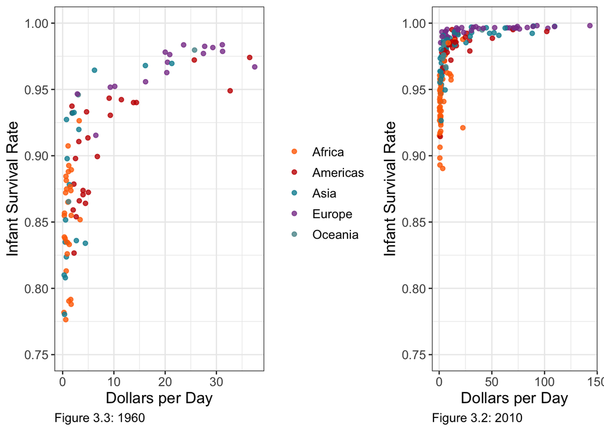

```r
# Update the 2010 graph so that the y-axis is consistent with 1960, and remove redundant captions and legend
plot3 <- plot1 + ylim(.75,1) + theme(legend.position = "none") + labs(x = "Dollars per Day", y = "Infant Survival Rate", caption = "Figure 3.2: 2010")
plot2 <- plot2 + ylim(.75,1) + labs(x = "Dollars per Day", y = "Infant Survival Rate", caption = "Figure 3.3: 1960")
grid.arrange(plot2, plot3, widths = c(5, 3))
```

The difference here is pretty cool!

## Paired Plot from 1960 to 2010

For this section, I decided to compare the change in infant survival countries in West Africa.

```r
gap.tot <- full_join(gap2010, gap1960)
gap.wafr <- gap.tot %>% filter(region == "Western Africa")
```

The original graph I made had a legend on the side, which I thought was confusing. I wanted to try and add the names directly to the graph. Spoiler alert: I did it, but even after much finagling with the annotation data frame, it still looked bad, and with the week that it’s been, I just didn’t have it in me to keep troubleshooting. I would just like to make sure that my peer reviewer knows that I think this graph is as ugly as you are sure to. Sorry.

```r
# Create data frame with just 2010 data, to avoid having two labels show up on the grapg
west.afr <- gap.wafr %>% filter(year == 2010)
# Set up the data frame to include country name, and the x and y coordinates where the labels should be placed on the graph. Adding 2 to the year helps prevent the text from overlapping the end point of the data, but causes its own quirks as we will see below
westafr.ann <- data.frame(country = west.afr$country, x = west.afr$year + 2, y = west.afr$infant_survival_rate)
# Ensure that this worked properly
head(westafr.ann)
```

```
##         country    x      y
## 1         Benin 2012 0.9290
## 2  Burkina Faso 2012 0.9303
## 3    Cape Verde 2012 0.9767
## 4 Cote d'Ivoire 2012 0.9231
## 5        Gambia 2012 0.9483
## 6         Ghana 2012 0.9498
```

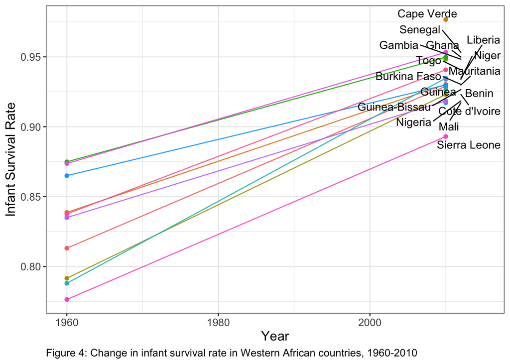

```r
# Looks good, proceed with plot
plot6 <- ggplot(data = gap.wafr, aes(x = year, y = infant_survival_rate, group = country)) + geom_line(aes(color = country), alpha = 0.9) + geom_point(aes(color = country)) + theme_bw() + geom_text_repel(data = westafr.ann, aes(x = x, y = y, label = country)) + theme(text = element_text(size=13), plot.caption = element_text(hjust = 0), legend.position = "none") + labs(x = "Year", y = "Infant Survival Rate", caption = "Figure 4: Change in infant survival rate in Western African countries, 1960-2010") + xlim(NA, 2015)
plot6
```

At least the information presented on the graph is good, right? All improvements in infant survival, and some countries managed to improve by quite a lot! As we can see, the labels are a total mess. I still personally think that this is an improvement over having the country labels in the legend, but improvement is entirely relative. This is something I can work on in future assignments.